# R Notebook

Outline:

Data import Exploratory data analysis Text mining (pairwise, correlation and topic modelling) Sentiment (changes over time, different sentiments for differnet factions, which sentiments lead to the most retweets / engagement)

```r
library(stm)
```

### Data import

```r
tweets <- read_csv("http://nodeassets.nbcnews.com/russian-twitter-trolls/tweets.csv")
```

```
There were 20 warnings (use warnings() to see them)
```

```r
paste(variables)
```

```
 [1] "user_id"               "user_key"              "created_at"            "created_str"
 [5] "retweet_count"         "retweeted"             "favorite_count"        "text"
 [9] "tweet_id"              "source"                "hashtags"              "expanded_urls"
[13] "posted"                "mentions"              "retweeted_status_id"   "in_reply_to_status_id"
[17] "party"
```

```r
users <- read_csv("http://nodeassets.nbcnews.com/russian-twitter-trolls/users.csv")
users <- read_csv("http://nodeassets.nbcnews.com/russian-twitter-trolls/users.csv")
head(users)
```

| id | location | name | followers_count | statuses_count | time_zone | verified | lang | screen_name | description | created_at | favourites_count | friends_count | listed_count |
| --- | --- | --- | --- | --- | --- | --- | --- | --- | --- | --- | --- | --- | --- |
| 100345056 | still \u2b06️Block⤵️Corner\u2b07️street | #Ezekiel2517\u2728... | 1053 | 31858 | NA | FALSE | en | SCOTTGOHARD | CELEBRITY TRAINER \u2728#424W147th\u2728 #CrossfitCoach #NSCA #IRepresentIntellectualViolence...Robinson Cano,Ice T,Missy Elliott, #EaglesDontFlyInFlocks... | Tue Dec 29 23:15:22 +0000 2009 | 2774 | 1055 | 35 |
| 247165706 | Chicago, IL | B E C K S T E R\u2728 | 650 | 6742 | Mountain Time (US & Canada) | FALSE | en | Beckster319 | Rebecca Lynn Hirschfeld Actress.Model.Writer.Amateur Race Car Driver. ~ Adorkable | Fri Feb 04 06:38:45 +0000 2011 | 7273 | 896 | 30 |
| 249538861 | NA | Chris Osborne | 44 | 843 | NA | FALSE | en | skatewake1994 | NA | Wed Feb 09 07:38:44 +0000 2011 | 227 | 154 | 1 |
| 449689677 | NA | Рамзан Кадыров | 94773 | 10877 | Moscow | FALSE | ru | KadirovRussia | Пародийный аккаунт. Озвучиваю то, что политикам не позволено протоколом | Thu Dec 29 11:31:09 +0000 2011 | 0 | 7 | 691 |
| 471868887 | Санкт-Петербург, Россия | Маргарита Саваж | 23305 | 18401 | Volgograd | FALSE | ru | MargoSavazh | Честь имею. Нагло врать не умею. | Mon Jan 23 10:26:25 +0000 2012 | 1480 | 8021 | 231 |
| 1039581360 | Amerika | Dark Nally | 22 | 22603 | Jakarta | FALSE | id | darknally | uptodate news!!!! | Thu Dec 27 13:06:58 +0000 2012 | 0 | 40 | 16 |

```r
names(users)
```

```
 [1] "id"               "location"         "name"             "followers_count"  "statuses_count"
 [6] "time_zone"        "verified"         "lang"             "screen_name"      "description"
[11] "created_at"       "favourites_count" "friends_count"    "listed_count"
```

### Exploratory Data Analysis

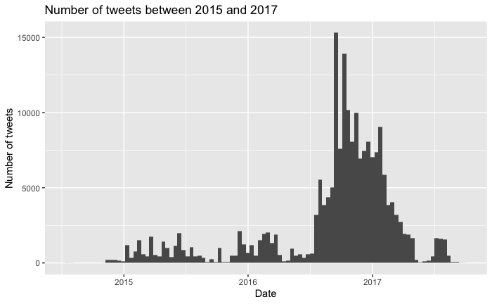

| created_str | n |
| --- | --- |
| 2016-10-06 | 3861 |
| 2016-09-17 | 3063 |
| 2016-11-08 | 2867 |
| 2016-09-19 | 2587 |
| 2016-09-18 | 2367 |
| 2016-10-07 | 2221 |
| 2016-09-16 | 1992 |
| 2016-10-19 | 1968 |
| 2016-10-10 | 1765 |
| 2016-09-12 | 1598 |

[output cut: 921 more lines]

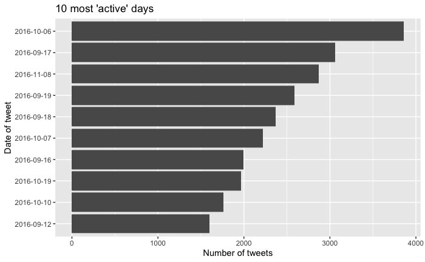

Interestingly, the days where the IRA were most active all fell in a short period around the autumn of 2016.

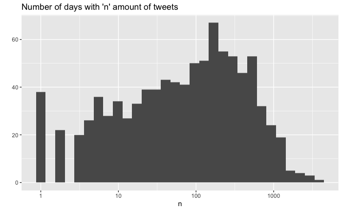

Some days (nearly 40) we saw as few as 1 tweet being published by the IRA, other days it could be as high as 4000.

```r
most_active_day <- tweets %>%
  mutate(created_str = floor_date(created_str, unit = "1 day")) %>%
  filter(created_str == as.Date("2016-10-06"))
```

I’m going to save this for later and do some textual analysis.

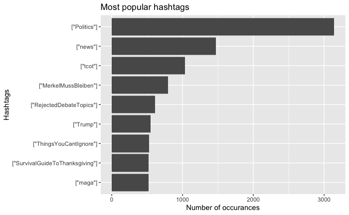

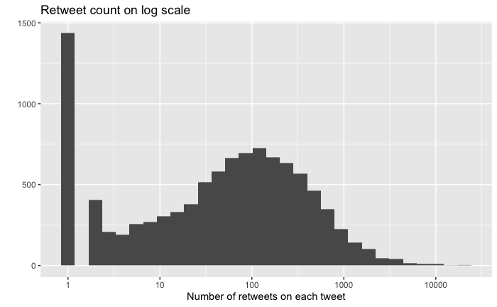

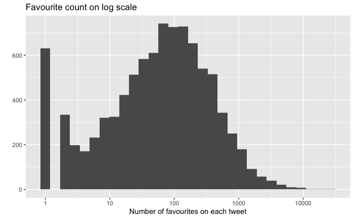

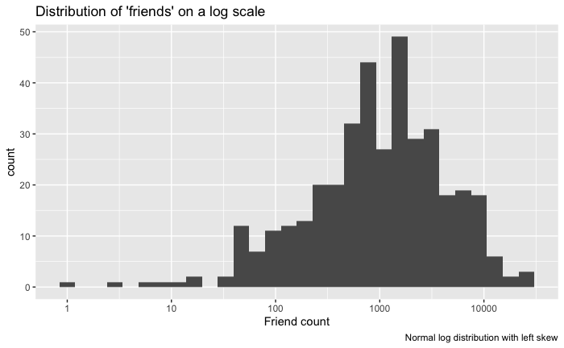

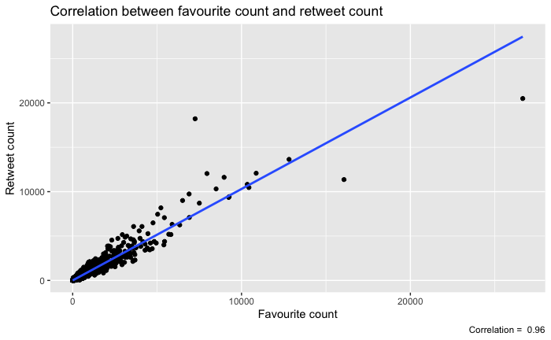

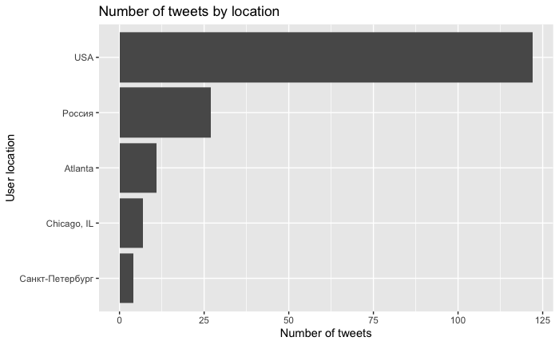

I find it interesting that some accounts are openly tweeting from Russia..

#### Key findings from EDA:** * There were accounts openly tweeting from Russia * Autumn of 2016 saw by far the heaviest activity * Some days saw as few as 1 tweet being published, others as high as 4000 * Hashtags were mainly political, with some non-political ones.

### Textual analysis - what themes come up?

```r
#For future use lets make a list of words we want to remove
custom_stop_words <- bind_rows(tibble(word = c("https", "t.co", "rt", "amp"),
                                      lexicon = c("custom")),
                               stop_words)
```

```r
tweets %>%
  count(user_key, sort = T) %>%
  head()
```

| user_key | n |
| --- | --- |
| ameliebaldwin | 9269 |
| hyddrox | 6813 |
| giselleevns | 6652 |
| patriotblake | 4140 |
| thefoundingson | 3663 |
| melvinsroberts | 3346 |

Amelia Baldwin is the most prolific twitter, accounting for nearly 5% of all tweets.

Lets check a sample of this accounts most engaged with tweets.

```r
amelia_baldwin <- tweets %>%
  filter(user_key == "ameliebaldwin")
amelia_baldwin %>%
  arrange(desc(retweet_count)) %>%
  head(n = 10) %>%
  select(text)
```

| text |
| --- |
| It's either working class "kills" her, or she kills working class\nSo make your choice!!!! #tcot https://t.co/LkLqJIT1o6 |
| We need to bring our country back from the edge of extinction!!! @realDonaldTrump #WakeUpAmerica https://t.co/bDnzjDya0R |
| You'd better read it before watching #debates \nhttps://t.co/wPo3W6sVU5 |
| First time ever voting in 38 Years! #ElectionDay #TrumpWinsBecause #TrumpPence16 . I BELIEVE ♡ #TrumpForPresident |
| CALLING ON ALL #TRUMP_VOTERS URGENT‼️ #TrumpPence16 #TrumpForPresident #PodestaEmails33 PLEASE RT RT RT ‼️ https://t… #TrumpForPresident |
| .@realDonaldTrump why would anyone vote for someone who will raise taxes, dilute 2nd amendment |
| I don't vote dems, but...poor Bernie https://t.co/u8O7V9kxKv |
| #ImNotWithHer #NeverHilary #TrumpPence16 #MakeAmericaGreatAgain https://t.co/2pmC6LygvS |
| RT @American_Woman4: #MAGA,#FEMININEAMERICA4TRUMP,#LGBT4Trump,#Fl4Trump Vote &amp; spread the true policies of Trump Happy Saturday\U0001f1fa\U0001f1f8 https://t… |
| RT @Conservatexian: News post: "TWITTER Buries 32 of Donald Trump\u0092s GOTO Battleground Tweets! \u0085Deletes Another!" https://t.co/XZLachsMsL |

Interestly, there is very little engagement (retweets, favourites) with the tweets. Particularly relevant given that all these tweets are coming from a network of accounts, that could certainly promote them more if wanted. Evidence of astro-turfing?

Lets see what she’s tweeting about more broadly:

```r
amelia_baldwin %>%
  filter(user_key == "ameliebaldwin") %>%
  unnest_tokens(word, text, token = "tweets") %>%
  filter(!word %in% custom_stop_words$word) %>%
  count(word, sort = T)
```

```
Using `to_lower = TRUE` with `token = 'tweets'` may not preserve URLs.
```

| word | n |
| --- | --- |
| trump | 1979 |
| clinton | 1094 |
| hillary | 1055 |
| @realdonaldtrump | 628 |
| obama | 604 |
| #maga | 446 |
| @hillaryclinton | 320 |
| people | 317 |
| donald | 290 |
| #trump | 276 |

[output cut: 990 more lines]

Lets check out that busiest day I identified earlier:

```
Using `to_lower = TRUE` with `token = 'tweets'` may not preserve URLs.
```

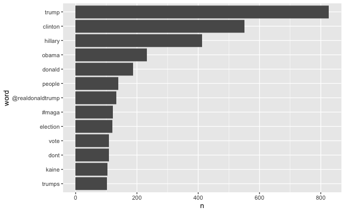

```r
most_active_day %>%
  unnest_tokens(word, text, token = "tweets") %>%
  filter(!word %in% custom_stop_words$word) %>%
  count(word, sort = T) %>%
  filter(n > 100) %>%
  mutate(word = reorder(word,n)) %>%
  ggplot(aes(word, n)) +
  geom_col() +
  coord_flip()
```

Hmm, not that much of interest. I wonder if there’s a better way to find out what themes were tweeted about on that day.

I’m going to try out topic modelling and see if it spots any different themes.

```r
most_active_tokens <- most_active_day %>%
  mutate(row = row_number()) %>%
  unnest_tokens(word, text, token = "tweets") %>%
  filter(!word %in% custom_stop_words$word)

most_active_dtm <-  most_active_tokens %>%
  count(row, word) %>%
  cast_dtm(row, word, n)

most_active_lda <- LDA(most_active_dtm, k = 64, control = list(seed = 1234))

most_active_topic_terms <- most_active_lda %>%
  tidy(matrix = "beta") %>%
  group_by(topic) %>%
  top_n(15, beta) %>%
  ungroup() %>%
  arrange(topic, -beta)

most_active_topic_terms %>%
  mutate(term = reorder(term, beta)) %>%
  ggplot(aes(x= term, y = beta, fill = topic)) +
  geom_col(show.legend = F) +
  facet_wrap(~ topic, scales = "free_y") +
  coord_flip()
```

[figure not shown]

OK, lets check out the whole corpus

| word | n |
| --- | --- |
| trump | 24138 |
| clinton | 10588 |
| hillary | 9710 |
| obama | 7336 |
| people | 6345 |
| dont | 5553 |
| donald | 4875 |
| @realdonaldtrump | 4007 |
| im | 3996 |
| #tcot | 3740 |

[output cut: 990 more lines]

They definitely were aiming to boost the profile of Trump

Now I’m going to look at bigram relations to see which words frequently come together.

```r
bigrams <- tweets %>%
  unnest_tokens(bigram, text, token = "ngrams", n = 2) #re-tokenise our tweets with bigrams.
bigrams_separated <- bigrams %>%
  separate(bigram, c("word_1", "word_2"), sep = " ")
bigrams_filtered <- bigrams_separated %>%
  filter(!word_1 %in% custom_stop_words$word) %>%
  filter(!word_2 %in% custom_stop_words$word)
bigram_counts <- bigrams_filtered %>%
  count(word_1, word_2 , sort = T)
```

| word_1 | word_2 | n |
| --- | --- | --- |
| donald | trump | 3972 |
| hillary | clinton | 3833 |
| white | house | 840 |
| tcot | ccot | 715 |
| bill | clinton | 667 |
| clinton | foundation | 609 |
| conservatexian | news | 577 |
| news | post | 577 |
| tcot | pjnet | 548 |
| trump | supporters | 478 |

[output cut: 27 more lines]

| item1 | item2 | n |
| --- | --- | --- |
| donald | trump | 4224 |
| trump | donald | 4224 |
| clinton | hillary | 4198 |
| hillary | clinton | 4198 |
| trump | clinton | 2565 |
| clinton | trump | 2565 |
| trump | hillary | 2262 |
| hillary | trump | 2262 |
| politics | trump | 1801 |
| trump | politics | 1801 |

[output cut: 72 more lines]

I don’t know what this ‘merkelmussbleiben’ means… lets take a look.

| text |
| --- |
| @johannesvogel würde Frau Merkel 4. Amtszeit schaffen? #Merkelmussbleiben |
| Vorwärts immer, rückwärts nimmer! #Merkelmussbleiben |
| #Merkel hält an Flüchtlings-Deal mit der #Türkei fest #Merkelmussbleiben |
| Sie ist nicht gleichgültig! #Merkelmussbleiben #girlstalkselfies |
| @BjoernMaatz sind die Chancen bei Bundeskanzlerin Merkel für 4. Amtszeit hoch? #Merkelmussbleiben |
| Ich glaub sie ist alternativlos! #Merkelmussbleiben |
| Mehr Platz für Familie #Merkelmussbleiben |
| Merkel ist nicht radikal, dennoch macht sie keine Rückschritte! #Merkelmussbleiben #girlstalkselfies |
| Es kommt mir vor, Frau Merkel hat alle Chancen für noch eine Amtszeit! #Merkelmussbleiben |
| #Merkel rettet Syrische leben #Merkelmussbleiben |

[output cut: 990 more lines]

OK so we see that it’s not just American politics but also German.

```r
table(users$lang)
```

```
 de  en  es  fr  id  ru
 18 272   1   1   1  90
```

[figure not shown]

Given everything here it’s really hard to conclude anything other than the IRA were overtly pro Trump Lets see what topic modelling reveals about different agendas.

### Topic modelling

tweets_dtm <- tweet_tokens %>% count(row, word) %>% cast_dtm(row, word, n)

tweets_lda <- LDA(tweets_dtm, k = 56, control = list(seed = 1234))

lda_gamma <- tidy(tweets_lda, matrix = “gamma”)

lda_gamma %>% arrange(desc(gamma))

### Sentiment analysis

Need do a bit more data cleaning. The issue is that when accounting for bigrams it doesn’t automatically consider whether words are preceded by a negation. This is still quite a rudimentary approach in a relatively nascent field of research, but will suffice for what we are intending to do.

[output not shown]

[output cut: 533 more lines]

```r
not_words %>%
  mutate(contribution = value * n) %>%
  arrange(desc(abs(contribution))) %>%
  top_n(25) %>%
  mutate(word_2 = reorder(word_2, contribution)) %>%
  ggplot(aes(word_2, contribution, fill = contribution > 0)) +
  geom_col(show.legend = F) +
  coord_flip() +
  labs(x = "Words preceded by a negative", y = "Sentiment score * number of occurances")
```

| word_2 | value | n | contribution |
| --- | --- | --- | --- |
| matter | -1 | 204 | -204 |
| forget | 1 | 156 | 156 |
| want | -1 | 85 | -85 |
| no | 1 | 83 | 83 |
| welcome | -2 | 62 | -124 |
| good | -3 | 57 | -171 |
| like | -2 | 55 | -110 |
| doubt | 1 | 54 | 54 |
| stop | 1 | 46 | 46 |
| problem | 2 | 45 | 90 |

[output cut: 533 more lines]

```r
sentiment <- tweet_tokens %>%
  count(word, sort = T) %>%
  inner_join(get_sentiments("afinn"), by = "word") %>%
  mutate(total_score = n * value)
sentiment
```

| word | n | value | total_score |
| --- | --- | --- | --- |
| love | 2558 | 3 | 7674 |
| stop | 1984 | -1 | -1984 |
| support | 1664 | 2 | 3328 |
| win | 1285 | 4 | 5140 |
| free | 1283 | 1 | 1283 |
| god | 1282 | 1 | 1282 |
| die | 1241 | -3 | -3723 |
| war | 1123 | -2 | -2246 |
| hate | 1103 | -3 | -3309 |
| supporters | 1084 | 1 | 1084 |

[output cut: 990 more lines]

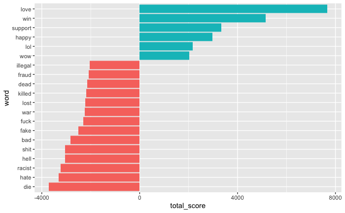

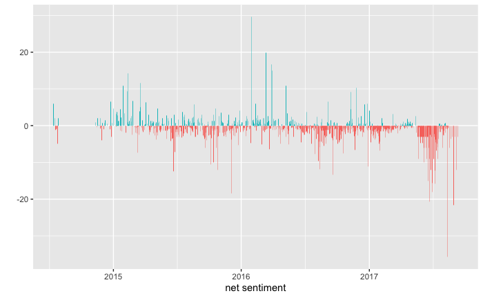

```r
sentiment_over_time %>%
  summarise(by_day = sum(total_score))  %>%
  arrange(desc(abs(by_day))) %>%
  mutate(row = row_number())
```

```r
sentiment_over_time %>%
  filter(created_str == as.Date("2016-07-21")) %>%
  summarise(sum = sum(total_score))
```

[output not shown]

[output cut: 75 more lines]

What the fuck is happening here. Look into it later.

I wanna see if there was a particular negative / positive association with certain topics or politicians. First lets identify these tweets:

```r
tweets$party <- NA
clinton <- c("Clinton", "Hillary", "Hillary Clinton")
trump <- c("Donald", "Trump", "Donald Trump")
obama <- c("Barack", "Obama", "Barack Obama")
sanders <- c("Bernie", "Sanders", "Bernie Sanders")
politicians <- c(clinton, trump, obama, sanders)
politicians <- paste(politicians, collapse = "|")
politicians <- tolower(politicians)

party_tweets <- tweets %>%
  mutate(text = tolower(text)) %>%
  filter(str_detect(text, politicians))
party_tweets$party <- str_extract(party_tweets$text, politicians)

party_tweets$party[party_tweets$party == "barack"] <- "Obama"
party_tweets$party[party_tweets$party == "obama"] <- "Obama"
party_tweets$party[party_tweets$party == "bernie"] <- "Sanders"
party_tweets$party[party_tweets$party == "sanders"] <- "Sanders"
party_tweets$party[party_tweets$party == "clinton"] <- "Clinton"
party_tweets$party[party_tweets$party == "hillary"] <- "Clinton"
party_tweets$party[party_tweets$party == "trump"] <- "Trump"
party_tweets$party[party_tweets$party == "donald"] <- "Trump"

table(party_tweets$party)
```

```r
tweets$party <- 1
clinton <- c("Clinton", "Hillary", "Hillary Clinton")
trump <- c("Donald", "Trump", "Donald Trump")
obama <- c("Barack", "Obama", "Barack Obama")
sanders <- c("Bernie", "Sanders", "Bernie Sanders")
politicians <- c(clinton, trump, obama, sanders)
politicians <- paste(politicians, collapse = "|")
politicians <- tolower(politicians)

party_tweets_all <- tweets %>%
  mutate(text = tolower(text)) %>%
  mutate(party = ifelse(str_detect(text, politicians) == TRUE, str_match(text, politicians), "No Party"))


party_tweets_all$party[party_tweets_all$party == "barack"] <- "Obama"
party_tweets_all$party[party_tweets_all$party == "obama"] <- "Obama"
party_tweets_all$party[party_tweets_all$party == "bernie"] <- "Sanders"
party_tweets_all$party[party_tweets_all$party == "sanders"] <- "Sanders"
party_tweets_all$party[party_tweets_all$party == "clinton"] <- "Clinton"
party_tweets_all$party[party_tweets_all$party == "hillary"] <- "Clinton"
party_tweets_all$party[party_tweets_all$party == "trump"] <- "Trump"
party_tweets_all$party[party_tweets_all$party == "donald"] <- "Trump"

table(party_tweets_all$party)
```

```r
party_tweets %>%
  ggplot(aes(party)) +
  geom_bar() +
  labs(Title = "Number of mentions of each politician", x = "Politician", y = "")
```

```r
party_tweets %>%
  ggplot(aes(created_str, fill = party)) +
  geom_histogram() +
  facet_wrap(~ party, scales= "free_y", ncol = 1)
```

```r
party_tweets %>%
  ggplot(aes(retweet_count)) +
  geom_histogram() +
  facet_wrap(~ party) +
  scale_x_log10()
```

```r
summary_of_retweets <- party_tweets %>%
  filter(!is.na(retweet_count)) %>%
  group_by(party) %>%
  summarise(total_rt = sum(retweet_count), num_of_tweets = sum(party == 'Clinton', party == 'Trump', party == 'Barack', party == 'Sanders')) %>%
  mutate(avg_rt = total_rt / num_of_tweets) %>%
  filter(!is.infinite(avg_rt))

summary_of_retweets %>%
  filter(num_of_tweets > 0) %>%
  ggplot(aes(party, avg_rt, fill = party)) +
  geom_col() +
  labs(x = "Party", y = "Average number of retweets")
```

```r
summary_of_retweets %>%
  na.omit() %>%
  aov(party ~ avg_rt, data = .)

aov_rts <- aov(summary_of_retweets$party ~ summary_of_retweets$avg_rt)
```

```r
trump <- party_tweets %>%
  filter(party == "Trump") %>%
  filter(!is.na(retweet_count))


clinton <- party_tweets %>%
  filter(party == "Clinton") %>%
  filter(!is.na(retweet_count))

t.test(trump$retweet_count ~ clinton$retweet_count)
```

Lets do some sentimental analysis

```r
party_tokens <- party_tweets %>%
  unnest_tokens(word, text, token = "tweets") %>%
  filter(word %in% custom_stop_words$word)

party_sentiment <- party_tokens %>%
  inner_join(get_sentiments("afinn"), by = "word")

party_sentiment_over_time <- party_sentiment %>%
  mutate(created_str = floor_date(created_str, unit = "1 day")) %>%
  add_count(created_str, word) %>%
  mutate(total_score = value * n) %>%
  group_by(created_str)
```

```r
party_sentiment_over_time %>%
  select(created_str, word, value, n, total_score, party) %>%
  arrange(desc(abs(total_score)))
```

[figure not shown]